# Unsupervised Learning: Trade&Ahead

#### Observations:

- Here, we use optimal ordering while calling linkage(). However, adopting this method somewhat slows down the process, it helps demonstrate the leaves and clusters of an HC model more visibly, when visualizing its dendrogram. Note that the only effect of optimal ordering is on visualization, and it doesn't impact the results of clustering in any other ways.
- To keep the comparison between the initial spatial distance of two data points and their dendrogramic distance fair and reasonable, we ensured that the distance metric in the linkage() and pdist() functions are identical.
- In the next step, we visualize the dendrogram of the top five models with highest cophenetic correlations along with when linkage method is set as 'ward'. It's been shown that Ward's method is highly skilled in rendering distinct and well-separated clusters, and perhaps for this reason, it's also selected as the default linkage method of Agglomerative Clustering.

**`Dendrogram`**

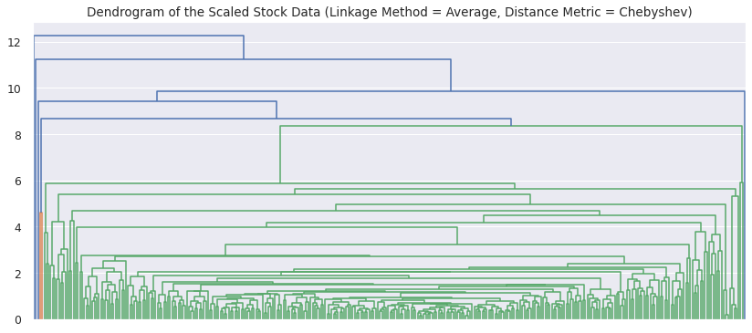

```python
# Dendrogram for the combination of hyperparameters leading to the highest cophenetic correlation
Z = linkage(df_model_scaled, method = 'average', metric = 'chebyshev', optimal_ordering = True)
plt.figure(figsize = (14, 6));
dendrogram(Z);
plt.title('Dendrogram of the Scaled Stock Data (Linkage Method = Average, Distance Metric = Chebyshev)');
plt.xticks([]);
```

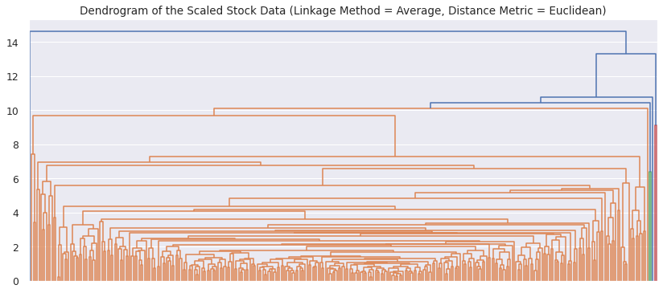

```python
# Dendrogram for the combination of hyperparameters leading to the 2nd highest cophenetic correlation
Z = linkage(df_model_scaled, method = 'average', metric = 'euclidean', optimal_ordering = True)
plt.figure(figsize = (14, 6));
dendrogram(Z);
plt.title('Dendrogram of the Scaled Stock Data (Linkage Method = Average, Distance Metric = Euclidean)');
plt.xticks([]);
```

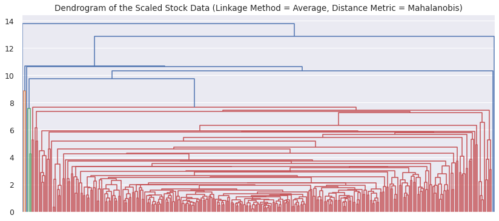

```python
# Dendrogram for the combination of hyperparameters leading to the 3rd highest cophenetic correlation
Z = linkage(df_model_scaled, method = 'average', metric = 'mahalanobis', optimal_ordering = True)
plt.figure(figsize = (14, 6));
dendrogram(Z);
plt.title('Dendrogram of the Scaled Stock Data (Linkage Method = Average, Distance Metric = Mahalanobis)');
plt.xticks([]);
```

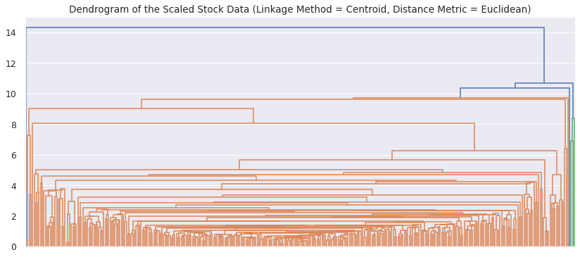

```python
# Dendrogram for the combination of hyperparameters leading to the 4th highest cophenetic correlation
Z = linkage(df_model_scaled, method = 'centroid', metric = 'euclidean', optimal_ordering = True)
plt.figure(figsize = (14, 6));
dendrogram(Z);
plt.title('Dendrogram of the Scaled Stock Data (Linkage Method = Centroid, Distance Metric = Euclidean)');
plt.xticks([]);
```

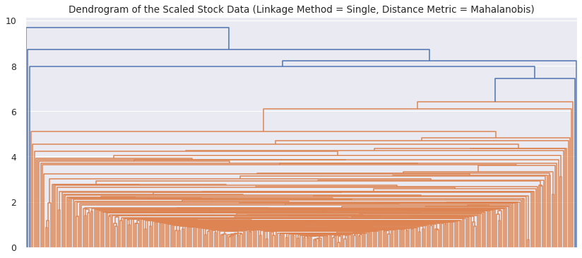

```python
# Dendrogram for the combination of hyperparameters leading to the 5th highest cophenetic correlation
Z = linkage(df_model_scaled, method = 'single', metric = 'mahalanobis', optimal_ordering = True)
plt.figure(figsize = (14, 6));
dendrogram(Z);
plt.title('Dendrogram of the Scaled Stock Data (Linkage Method = Single, Distance Metric = Mahalanobis)');
plt.xticks([]);
```

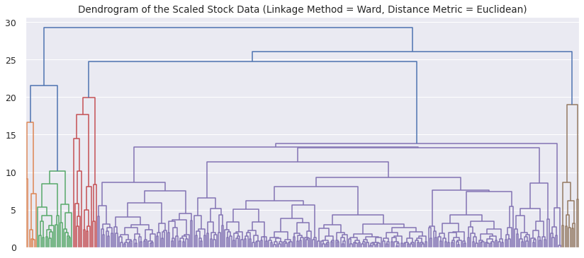

```python
# Dendrogram for when Ward's method is set as the linkage method
Z = linkage(df_model_scaled, method = 'ward', metric = 'euclidean', optimal_ordering = True)
plt.figure(figsize = (14, 6));
dendrogram(Z);
plt.title('Dendrogram of the Scaled Stock Data (Linkage Method = Ward, Distance Metric = Euclidean)');
plt.xticks([]);
```

#### Observations:

- As we'd suspected earlier, adopting Ward's method for the linkage of leaves (sub-clusters) in an HC model, despite not having the highest cophenetic correlation, yields far more meaningful, interpretable, distinct and well-separated clusters, in comparison with all other models. Regardless, the cophenetic correlation coefficient of the model provided by Ward's method is still fairly good and above 0.7.
- We thus use Euclidean as the distanc metric and Ward's method as the linkage method, while building the final HC model. As mentioned before, Ward's method only works with the Euclidean measure.

**`Silhouette Scores`**

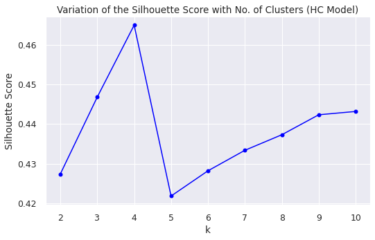

```python
# Defining silhouette scores array
sil_scores = np.zeros(len(no_clusters)-1)

# Looping over no. of clusters to calculate the average silhouette score of each
for k in no_clusters[1:]:
    clust_model = AgglomerativeClustering(n_clusters = k, affinity = 'euclidean', linkage = 'ward')
    segments = clust_model.fit_predict(df_model_scaled)
    sil_scores[k-2] = silhouette_score(df_model_scaled, clust_model.labels_)

# Plotting mean distortions vs. k
plt.figure(figsize = (8.4, 5));
plt.plot(no_clusters[1:], sil_scores, color = 'blue', marker = 'o');
plt.xlabel('k');
plt.ylabel('Silhouette Score');
plt.title('Variation of the Silhouette Score with No. of Clusters (HC Model)');
```

#### Observations:

For the given linkage method and distance metric, k = 4 results in the highest silhouette score. Four clusters also look fairly good on the dendrogram plot. Therefore, we'll set the number of clusters in our HC model as 4.

### Final Model

```python
# Copying the scaled data into a new dataframe to ensure it remains untouched for the rest of calculations
df_hc_scaled = df_model_scaled.copy()
# Implementing the final hierarchical clustering using the 'best' linkage method & distance metric
t_i = time()
HC_final_model = AgglomerativeClustering(n_clusters = 4, affinity = 'euclidean', linkage = 'ward')
HC_segments = HC_final_model.fit_predict(df_model_scaled)
t_e = time()
print('The execution of hierarchical clustering takes {} seconds.'.format(round(t_e - t_i, 4)))
# Adding the clusters introduced by k-means model to the dataframes
df_hc_scaled['Segment'] = HC_segments
df_model['HC Segment'] = HC_segments
```

```
The execution of hierarchical clustering takes 0.0093 seconds.
```

### Cluster Profiling

```python
# Separating the data points of each cluster and indicating each cluster by its centroid
hc_clust_profile = df_model.groupby('HC Segment').mean()
# Adding the number of data points in each cluster to the cluster profiling
hc_clust_profile['Count'] = df_model['HC Segment'].value_counts()[np.sort(df_model
                                                                               ['HC Segment'].value_counts().index)]
hc_clust_profile.drop(columns = 'K-Means Segment').style.highlight_max(color = 'lightgreen', axis = 0)
```

| HC Segment | Current Price | Price Change | Volatility | ROE | Cash Ratio | Net Cash Flow | Net Income | Earnings per Share | Outstanding Shares | P/E Ratio | P/B Ratio | Count |
| --- | --- | --- | --- | --- | --- | --- | --- | --- | --- | --- | --- | --- |
| 0 | 48.006208 | -11.263107 | 2.590247 | 196.551724 | 40.275862 | -495901724.137931 | -3597244655.172414 | -8.689655 | 486319827.294483 | 75.110924 | -2.162622 | 29 |
| 1 | 326.198218 | 10.563242 | 1.642560 | 14.400000 | 309.466667 | 288850666.666667 | 864498533.333333 | 7.785333 | 544900261.301333 | 113.095334 | 19.142151 | 15 |
| 2 | 42.848182 | 6.270446 | 1.123547 | 22.727273 | 71.454545 | 558636363.636364 | 14631272727.272728 | 3.410000 | 4242572567.290909 | 15.242169 | -4.924615 | 11 |
| 3 | 72.760400 | 5.213307 | 1.427078 | 25.603509 | 60.392982 | 79951512.280702 | 1538594322.807018 | 3.655351 | 446472132.228456 | 24.722670 | -2.647194 | 285 |

#### Observations:

- Cluster 0 consists of struggling companies with negative recent price change and high-volatility stock prices. The average net income, net cash flow and earnings per share of this cluster is also below zero, suggesting that most companies in this cluster are suffering huge losses. The fairly high P/E ratio of this cluster can also indicate that stocks of this cluster are on average overvalued.
- Cluster 1 is made up of highly profitable companies (the largest earnings per share, cash ratios and highest stock prices) with a fairly strong net cash flow and a decdent net income. These companies have also experience the largest price rise compared to those in the other clusters. The somewhat low value of shares outstanding may indicate these are perhaps mid-sized and rapidly growing businesses. The very high P/E and P/B ratios also imply that the stocks of this cluster are most likely overvalued and past their peak prices. This cluster is the only one with a positive P/B ratio, suggesting that only the companies in this cluster, on average, have more total assets than liabilities.
- Cluster 2 represents giant corporates with very large net cash flows, net incomes and shares outstanding. However the stock prices of this cluster is lower than the other three, but, on average, companies in this cluster have decent price rises, fairly good eranings per share, reasonable P/E ratios and low volatility indices, meaning that someone investing in these companies can expect a reliable and steadily growing source of income.
- The overwhelming majority of companies (84%) fall in cluster 3. The average stock price of this cluster is moderate (only lower than cluster 1), and it also has a fairly high earnings per share (again, second to cluster 1). The cash flow of this cluster is positive, but much lower than those of cluster 1 and 2. Its net income also falls somewhere between cluster 1 and 2. The volatility and P/E ratio of this cluster are moderate, indicating that its stock prices are fairly reliable. This cluster includes the biggest bulk of companies, so, unsurprisngly, most properties of this cluster are modest and somewhere in the middle.

```python
# Printing the name of companies in each cluster
for k in range(4):
    print('All companies in cluster ', k, ':\n',
          np.array(df.loc[df_model['HC Segment'] == k]['Security'].values.tolist()), sep = '', end = '\n'*2)
```

```
All companies in cluster 0:
['Allegion' 'Apache Corporation' 'Anadarko Petroleum Corp'
 'Baker Hughes Inc' 'Chesapeake Energy' 'Charter Communications'
 'Colgate-Palmolive' 'Cabot Oil & Gas' 'Concho Resources'
 'Devon Energy Corp.' 'EOG Resources' 'Freeport-McMoran Cp & Gld'
 'Hess Corporation' 'Kimberly-Clark' 'Kinder Morgan' 'Marathon Oil Corp.'
 'Murphy Oil' 'Noble Energy Inc' 'Newfield Exploration Co'
 'National Oilwell Varco Inc.' 'ONEOK' 'Occidental Petroleum'
 'Range Resources Corp.' 'Spectra Energy Corp.' 'S&P Global, Inc.'
 'Southwestern Energy' 'Teradata Corp.' 'Williams Cos.' 'Cimarex Energy']

All companies in cluster 1:
['Alliance Data Systems' 'Alexion Pharmaceuticals' 'Amgen Inc'
 'Amazon.com Inc' 'Chipotle Mexican Grill' 'Equinix' 'Facebook'
 'Frontier Communications' 'Intuitive Surgical Inc.' 'Monster Beverage'
 'Netflix Inc.' 'Priceline.com Inc' 'Regeneron' 'Waters Corporation'
 'Yahoo Inc.']

All companies in cluster 2:
['Bank of America Corp' 'Citigroup Inc.' 'Ford Motor' 'Intel Corp.'
 'JPMorgan Chase & Co.' 'Coca Cola Company' 'Pfizer Inc.' 'AT&T Inc'
 'Verizon Communications' 'Wells Fargo' 'Exxon Mobil Corp.']

All companies in cluster 3:
['American Airlines Group' 'AbbVie' 'Abbott Laboratories'
 'Adobe Systems Inc' 'Analog Devices, Inc.' 'Archer-Daniels-Midland Co'
 'Ameren Corp' 'American Electric Power' 'AFLAC Inc'
 'American International Group, Inc.' 'Apartment Investment & Mgmt'
 'Assurant Inc' 'Arthur J. Gallagher & Co.' 'Akamai Technologies Inc'
 'Albemarle Corp' 'Alaska Air Group Inc' 'Allstate Corp'
 'Applied Materials Inc' 'AMETEK Inc' 'Affiliated Managers Group Inc'
 'Ameriprise Financial' 'American Tower Corp A' 'AutoNation Inc'
 'Anthem Inc.' 'Aon plc' 'Amphenol Corp' 'Arconic Inc'
 'Activision Blizzard' 'AvalonBay Communities, Inc.' 'Broadcom'
 'American Water Works Company Inc' 'American Express Co' 'Boeing Company'
 'Baxter International Inc.' 'BB&T Corporation' 'Bard (C.R.) Inc.'
 'BIOGEN IDEC Inc.' 'The Bank of New York Mellon Corp.' 'Ball Corp'
 'Bristol-Myers Squibb' 'Boston Scientific' 'BorgWarner'
 'Boston Properties' 'Caterpillar Inc.' 'Chubb Limited' 'CBRE Group'
 'Crown Castle International Corp.' 'Carnival Corp.' 'Celgene Corp.'
```

[output cut: 58 more lines]

```
 'Synchrony Financial' 'Stryker Corp.' 'Molson Coors Brewing Company'
 'Tegna, Inc.' 'Torchmark Corp.' 'Thermo Fisher Scientific' 'TripAdvisor'
 'The Travelers Companies Inc.' 'Tractor Supply Company' 'Tyson Foods'
 'Tesoro Petroleum Co.' 'Total System Services' 'Texas Instruments'
 'Under Armour' 'United Continental Holdings' 'UDR Inc'
 'Universal Health Services, Inc.' 'United Health Group Inc.' 'Unum Group'
 'Union Pacific' 'United Parcel Service' 'United Technologies'
 'Varian Medical Systems' 'Valero Energy' 'Vulcan Materials'
 'Vornado Realty Trust' 'Verisk Analytics' 'Verisign Inc.'
 'Vertex Pharmaceuticals Inc' 'Ventas Inc' 'Wec Energy Group Inc'
 'Whirlpool Corp.' 'Waste Management Inc.' 'Western Union Co'
 'Weyerhaeuser Corp.' 'Wyndham Worldwide' 'Wynn Resorts Ltd'
 'Xcel Energy Inc' 'XL Capital' 'Dentsply Sirona' 'Xerox Corp.'
 'Xylem Inc.' 'Yum! Brands Inc' 'Zimmer Biomet Holdings' 'Zions Bancorp'
 'Zoetis']
```

```python
# Grouping data points of each cluster based on their economic sector
pd.crosstab(df_model['HC Segment'], df_model['GICS Sector']).style.highlight_max(
                                                                    color = 'lightgreen', axis = 1)
```

| GICS Sector HC Segment | Consumer Discretionary | Consumer Staples | Energy | Financials | Healthcare | IT | Industrials | Materials | Real Estate | Telecommunications | Utilities |
| --- | --- | --- | --- | --- | --- | --- | --- | --- | --- | --- | --- |
| 0 | 1 | 2 | 22 | 1 | 0 | 1 | 1 | 1 | 0 | 0 | 0 |
| 1 | 3 | 1 | 0 | 0 | 5 | 4 | 0 | 0 | 1 | 1 | 0 |
| 2 | 1 | 1 | 1 | 4 | 1 | 1 | 0 | 0 | 0 | 2 | 0 |
| 3 | 35 | 15 | 7 | 44 | 34 | 27 | 52 | 19 | 26 | 2 | 24 |

#### Observations:

- Cluster 0, which was characterized by declining stock prices and high volatility, is predictably dominated by Energy companies, which also have these two properties.
- Cluster 1, which consists of rapidly growing and highly prosperous businesses, is unsurprisingly filled with big names in IT (e.g., Netflix and Amazon) and pharmaceutical (e.g., Regeneron and Alexion) industries. We remark that, in recent years, both sectors have experienced phenomenal growth.
- Cluster 2 represents internationally-recognized, massive corporations, with really large net cash flows and net incomes. Therefore, it is not surprising to see several prominent financial institutions (e.g., Bank of America, Citigroup and JPMorgan Chase) present in this cluster.
- Cluster 3 describes average (moderately successful) performance, so, expectedly, the majority of companies from all sectors (except Energy and Telecommunications) reside in this cluster.

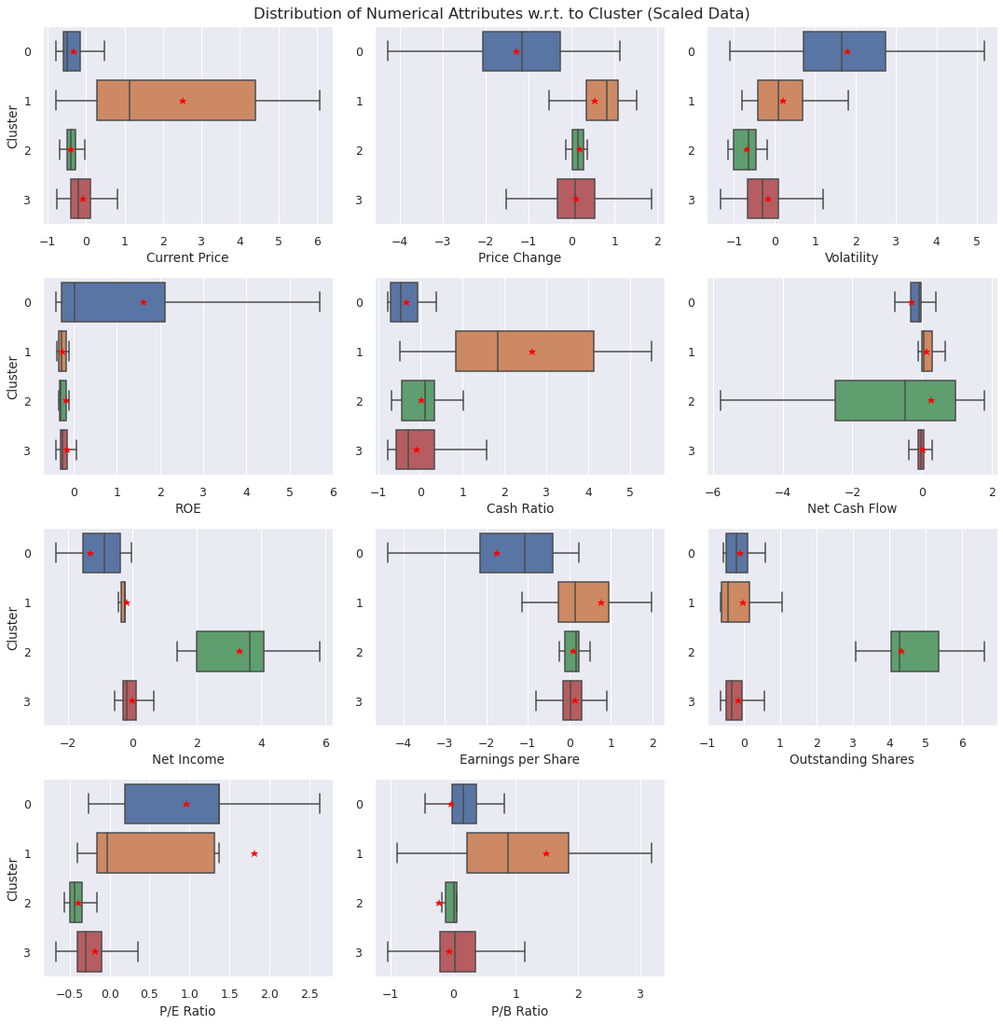

```python
# Demonstrating the boxplots of numerical variables for each cluster (scaled data)
plt.figure(figsize = (16, 16));
plt.suptitle('Distribution of Numerical Attributes w.r.t. to Cluster (Scaled Data)');
for i, col in enumerate(df_hc_scaled.drop(columns = 'Segment').columns.tolist()):
    plt.subplot(4, 3, i+1);
    sns.boxplot(data = df_hc_scaled, x = col, y = 'Segment', showmeans = True, showfliers = False, orient = 'h',
                meanprops = {'marker': '*', 'markerfacecolor': 'red', 'markeredgecolor': 'red', 'markersize': '9'});
    if(i%3 == 0):
      plt.ylabel('Cluster');
    else:
      plt.ylabel('');
plt.tight_layout(pad = 3.3, h_pad = 1, w_pad = 1.5);
```

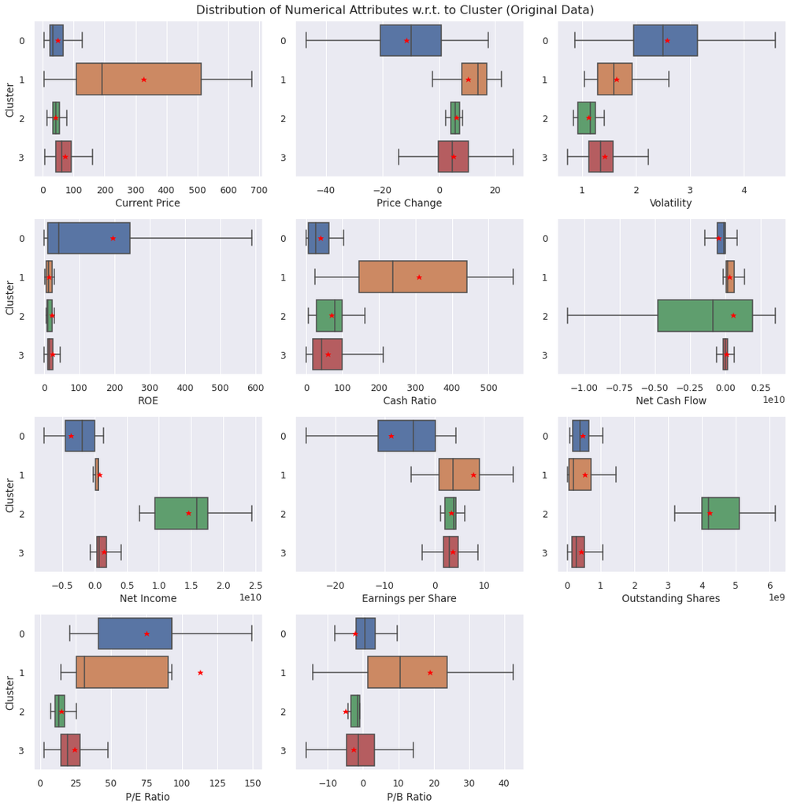

```python
# Demonstrating the boxplots of numerical variables for each cluster (original data)
plt.figure(figsize = (16, 16));
plt.suptitle('Distribution of Numerical Attributes w.r.t. to Cluster (Original Data)');
for i, col in enumerate(df_model.drop(
              columns = ['K-Means Segment', 'HC Segment']).select_dtypes(include = np.number).columns.tolist()):
    plt.subplot(4, 3, i+1);
    sns.boxplot(data = df_model, x = col, y = 'HC Segment', showmeans = True, showfliers = False, orient = 'h',
                meanprops = {'marker': '*', 'markerfacecolor': 'red', 'markeredgecolor': 'red', 'markersize': '9'});
    if(i%3 == 0):
      plt.ylabel('Cluster');
    else:
      plt.ylabel('');
plt.tight_layout(pad = 3.3, h_pad = 1, w_pad = 1.5);
```

## K-means vs. Hierarchical Clustering

**Questions**:

- Which clustering technique took less time for execution?
- Which clustering technique gave you more distinct clusters, or are they the same?
- How many observations are there in the similar clusters of both algorithms?
- How many clusters are obtained as the appropriate number of clusters from both algorithms?

You can also mention any differences or similarities you obtained in the cluster profiles from both the clustering techniques.

```python
print('Silhouette score of the final k-means model:',
        round(silhouette_score(df_model_scaled, kmeans_final_model.labels_), 3))
print('Silhouette score of the final HC model:',
        round(silhouette_score(df_model_scaled, HC_final_model.labels_), 3))
```

```
Silhouette score of the final k-means model: 0.464
Silhouette score of the final HC model: 0.465
```

**Responses**:

- Both methods took only in the order of hundredth of a second, but we should note that the dataset of this project is small. When a very large dataset is dealt with, hierarchical clustering is expected to take much longer, since its execution time scales with the square of the number of data points, whereas that of k-means algorithm scales linearly.
- The optimal numbers of clusters for the k-means and HC models were found to be equal to 3 and 4, respectively.
- The silhouette score of both models are very close to each other, i.e. both models, on average, have done a similar job in placing the data points in the proper (closest) cluster.
- The cluster pertaining to the highly prosperous IT and Biotech companies (cluster 1) detected by the HC model went fully unnoticed by the k-means algorithm, i.e. the HC model performed better in identifying more distinct and meaningful clusters. Most observations in cluster 1 of the HC model are placed in cluster 2 (average performance) by the k-means algorithm.
- With the exception of the thriving tech companies neglected by the k-means model, both clustering techniques identified very similar and analogous clusters:
  1. High-volatility stocks with declining prices (mostly from the Energy sector): Cluster 1 of the k-means model and cluster 0 of the HC model.
  2. Giant and internationally prominent corporations with very large net incomes, cash flows and shares outstanding: Cluster 0 of the k-means model and cluster 2 of the HC model.
  3. Companies with an average performance, whose price rise, net income and cash flow are fairly moderate: Cluster 2 of the k-means model and cluster 3 of the HC model. This cluster makes the bulk of the dataset.
- The number of observations in the main three clusters discussed above are also fairly similar between the two models, but, evidently, since the HC model has one additional cluster, fewer data points fall in the three primary clusters. The table below describes the distribution of the data points among these three clusters for both models.
- Despite all similarities between the cluster 1 of k-means model and the cluster 0 of the HC model, both corresponding to struggling companies, which mostly come from the Energy sector, the net cash flow of the latter is negative, while that of the former is positive. This might have been caused by some outliers and/or incongruent data points falling in the cluster 1 of the k-means model.

```python
# Building a dataframe for the number of data points in the main clusters
# and the percentage of the dataset each occupies
main_clusters_df = pd.DataFrame(columns = ['Cluster', 'No. of Observations (K-Means)', 'No. of Observations (HC)',
                                           '% of the Data (K-Means)', '% of the Data (HC)'])

main_clusters_df['Cluster'] = ['Struggling Companies', 'Giant Corps', 'Average Performance', 'Highly Prosperous']
main_clusters_df['No. of Observations (K-Means)'] = [32, 14, 294, 0]
main_clusters_df['No. of Observations (HC)'] = [29, 11, 285, 15]
main_clusters_df['% of the Data (K-Means)'] = main_clusters_df['No. of Observations (K-Means)']/df.shape[0]*100
main_clusters_df['% of the Data (HC)'] = main_clusters_df['No. of Observations (HC)']/df.shape[0]*100
main_clusters_df.replace(0, 'N/A', inplace = True)
main_clusters_df
```

|  | Cluster | No. of Observations (K-Means) | No. of Observations (HC) | % of the Data (K-Means) | % of the Data (HC) |
| --- | --- | --- | --- | --- | --- |
| 0 | Struggling Companies | 32 | 29 | 9.412 | 8.529 |
| 1 | Giant Corps | 14 | 11 | 4.118 | 3.235 |
| 2 | Average Performance | 294 | 285 | 86.471 | 83.824 |
| 3 | Highly Prosperous | N/A | 15 | N/A | 4.412 |

## Actionable Insights and Recommendations

*Key observations:*

- We leveraged k-means algorithm and hierarchical clustering to group the stock data of a few hundred companies into informative and interpretable clusters from business point of view. Three primary clusters (struggling companies (mostly from the energy sector), giant corporations and companies with modest performance) emerged from both techniques. On additional cluster, pertaining to thriving biotech and IT companies, lacking in the k-means model, was also identified by the HC model.
- The dataset consisted of the stock information of 340 NYSE companies, distributed in 11 economic sectors and 104 sub-industries, with the Industrials sector and the O&G Exploration & Production sub-industry being the most frequent classes, respectively. Since there are too many sub-industries, some with only a few data points, only the effect of economic sector on financial (stock) performance and clustering was analyzed.
- Both models revealed similar silhouette scores and execution times. The latter won't hold for much larger datasets, as hierarchical clustering scales with the square of the number of observations, whereas k-means algorithm scales linearly, creating an inevitable and huge gap between their execution times when massive datasets are dealt with.
- Among all numerical variables, stock price has the strongest correlation with earnings per share. The latter is highly and positively correlated with net income.
- High volatility usually translates to declining stock prices.
- The largest price increase and decrease have occured for the Healthcare and Energy sectors, respectively. The latter is also the most volatile sector, while Utilities sector shows to have the most steady stock prices.

*Business insights:*

- At the moment, the Energy sector seems the most precarious one for investment, with big losses and high volatility.
- Giant corporations, especially mammoth and internationally prominent financial institutions, appear to be the safest choice for investment. Although their price increase may not be as big as other business groups, but their low volatility and reasonable P/E ratio suggest a steady and reliable growth.
- Presently, the entrepreneurial Biotech and IT firms exhibit phenomenal growth with high eranings per share and large sums of cash available. Although one should be wary of their high P/E and P/B ratios.
- Overall, one should be careful not to be deceived by the current high stock price of some companies or their recent rapid growth and price increase. In order to have a smart investment and not to be surprised by an upcoming price dip, one should also take other factors such as a company's P/E and P/B ratios as well as its liabilities and debts into consideration.

*Recommendations for future ML-based modeling:*

- Treatment of outliers doesn't appear to be a good idea, at least in this project, as it can lead to the elimination of clusters pertaining to excellent or terribly poor performance.
- Addition of more observations to the dataset might enable us to have a more fair and balanced view of sectors and industries, which currently have only a few data points.
- The optimal number of clusters shows to be somewhat subjective and dependent on domain knowledge, especially when carrying out k-means clustering, therefore consulting a domain expert in choosing a reasonable number for k is highly recommended, to ensure all generated clusters are meaningful and interpretable. Nonetheless, a legitimate piece of advice is that going for more and more clusters isn't always a good idea, as it may lead to the introduction of unnecessary, overlapping and artificial clusters.